# InVivoStat Single Measure Parametric Analysis

## Response and covariate

The Resp7 response is currently being analysed by the Single Measures Parametric Analysis module, with Cov 1 and Resp 1 fitted as covariates.The covariates have been Square Root transformed prior to analysis.

## Scatterplot of the raw data

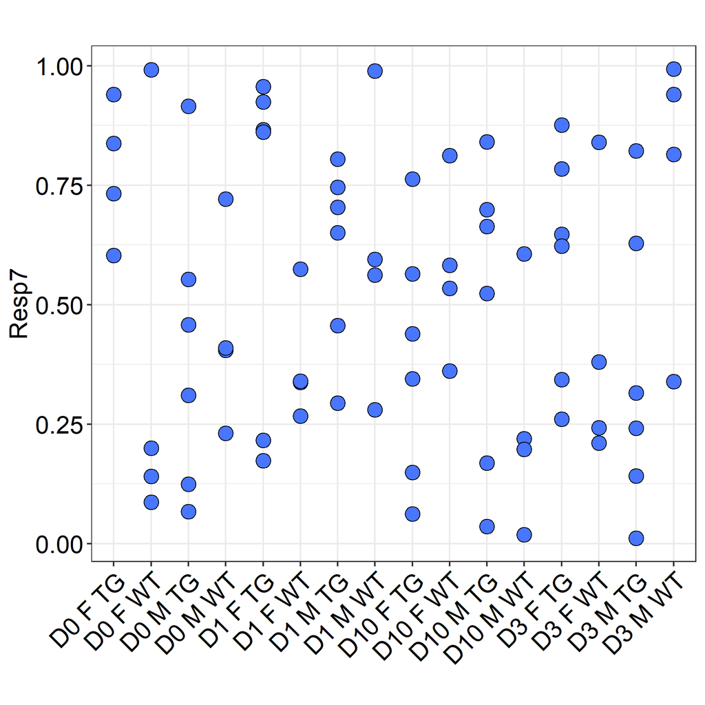

Tip: Use this plot to identify possible outliers.

## Plot of the response vs. the covariates, categorised by the primary factor (on the transformed scale)

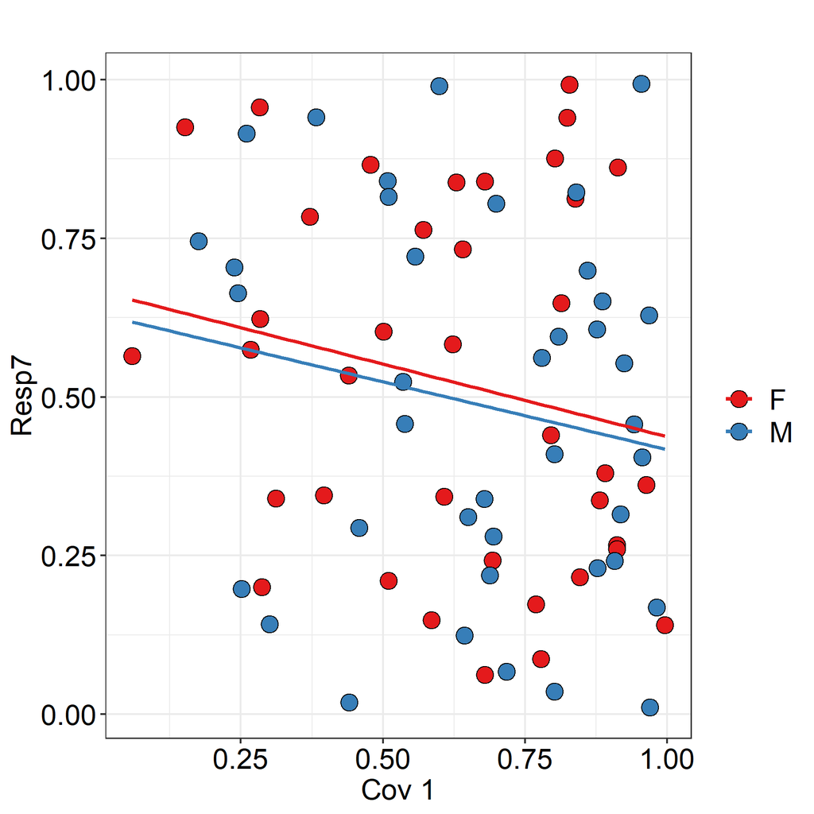

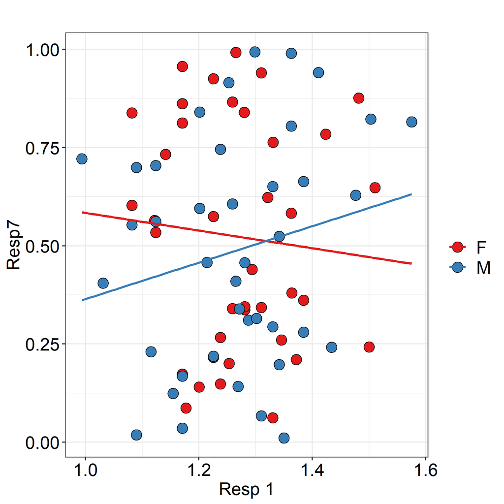

Tip: In order to decide whether it is helpful to fit the covariate, the following should be considered:

a) Is there a relationship between the response and the covariate? (N.B., It is only worth fitting the covariate if there is a strong positive (or negative) relationship between them: i.e., the lines on the plot should not be horizontal).

b) Is the relationship similar for all treatments? (The lines on the plot should be approximately parallel).

c) Is the covariate influenced by the treatment? (We assume the covariate is not influenced by the treatment and so there should be no separation of the treatment groups along the x-axis on the plot).

These issues are discussed in more detail in Morris (1999).

## Analysis of Covariance (ANCOVA) table

| Effect | Sums of squares | Degrees of freedom | Mean square | F-value | p-value |
| --- | --- | --- | --- | --- | --- |
| Cov 1 | 0.280 | 1 | 0.280 | 3.74 | 0.0580 |
| Resp 1 | 0.088 | 1 | 0.088 | 1.18 | 0.2826 |
| Blo ck1 | 0.099 | 1 | 0.099 | 1.32 | 0.2547 |
| Treat1 | 0.207 | 3 | 0.069 | 0.92 | 0.4367 |
| Treat2 | 0.004 | 1 | 0.004 | 0.05 | 0.8266 |
| Treat3 | 0.037 | 1 | 0.037 | 0.49 | 0.4873 |
| Treat1 * Treat2 | 0.166 | 3 | 0.055 | 0.74 | 0.5352 |
| Treat1 * Treat3 | 0.198 | 3 | 0.066 | 0.88 | 0.4574 |
| Treat2 * Treat3 | 0.240 | 1 | 0.240 | 3.19 | 0.0791 |
| Treat1 * Treat2 * Treat3 | 0.836 | 3 | 0.279 | 3.72 | 0.0162 |
| Residual | 4.427 | 59 | 0.075 |  |  |

Comment: ANCOVA table calculated using a Type III model fit, see Armitage et al. (2001).

Conclusion: There is a statistically significant overall difference between the levels of Treat1:Treat2:Treat3.

Tip: While it is a good idea to consider the overall tests in the ANCOVA table, we should not rely on them when deciding whether or not to make pairwise comparisons.

## Diagnostic plots

### Residuals vs. predicted plot

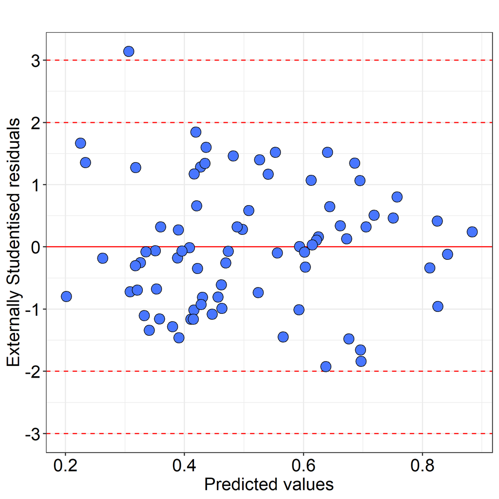

Tip: On this plot look to see if the spread of the points increases as the predicted values increase. If so the response may need transforming.

Tip: Any observation with a residual less than -3 or greater than 3 (SD) should be investigated as a possible outlier.

### Normal probability plot

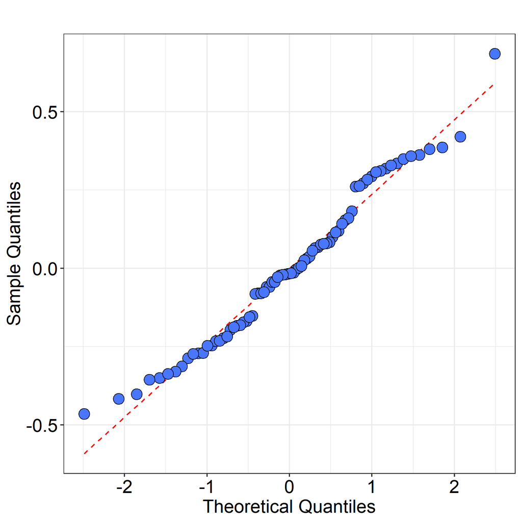

Tip: Check that the points lie along the dotted line. If not then the data may be non-normally distributed.

## Plot of the least square (predicted) means with 95% confidence intervals

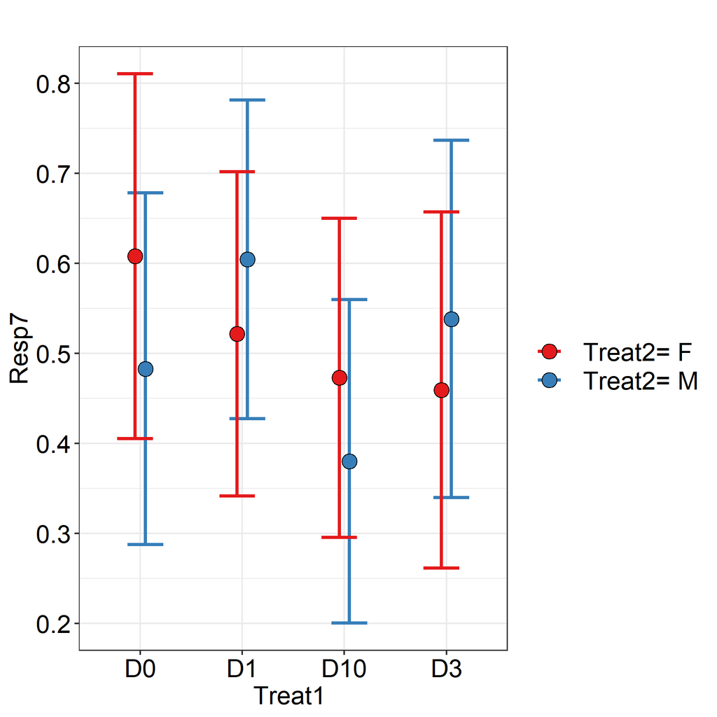

## Table of the least square (predicted) means with 95% confidence intervals

| Mean ID | Treat1 | Treat2 | Mean | Lower 95% CI | Upper 95% CI |
| --- | --- | --- | --- | --- | --- |
| 1 | D0 | F | 0.608 | 0.405 | 0.811 |
| 2 | D1 | F | 0.522 | 0.341 | 0.702 |
| 3 | D10 | F | 0.473 | 0.295 | 0.650 |
| 4 | D3 | F | 0.459 | 0.261 | 0.657 |
| 5 | D0 | M | 0.483 | 0.287 | 0.678 |
| 6 | D1 | M | 0.604 | 0.428 | 0.781 |
| 7 | D10 | M | 0.380 | 0.200 | 0.559 |
| 8 | D3 | M | 0.538 | 0.340 | 0.737 |

## All pairwise comparisons using Hommel's procedure

| Comparison | Difference | Lower 95% CI | Upper 95% CI | Std error | p-value |
| --- | --- | --- | --- | --- | --- |
| D0,F - D1,F | 0.086 | -0.179 | 0.352 | 0.133 | 0.9804 |
| D0,F - D10,F | 0.135 | -0.134 | 0.404 | 0.134 | 0.9804 |
| D0,F - D3,F | 0.149 | -0.152 | 0.450 | 0.150 | 0.9804 |
| D0,F - D0,M | 0.125 | -0.138 | 0.388 | 0.132 | 0.9804 |
| D0,F - D1,M | 0.003 | -0.267 | 0.273 | 0.135 | 0.9804 |
| D0,F - D10,M | 0.228 | -0.037 | 0.493 | 0.132 | 0.9804 |
| D0,F - D3,M | 0.070 | -0.231 | 0.370 | 0.150 | 0.9804 |
| D1,F - D10,F | 0.049 | -0.203 | 0.301 | 0.126 | 0.9804 |
| D1,F - D3,F | 0.063 | -0.215 | 0.340 | 0.138 | 0.9804 |
| D1,F - D0,M | 0.039 | -0.219 | 0.297 | 0.129 | 0.9804 |
| D1,F - D1,M | -0.083 | -0.336 | 0.170 | 0.126 | 0.9804 |
| D1,F - D10,M | 0.142 | -0.109 | 0.392 | 0.125 | 0.9804 |
| D1,F - D3,M | -0.016 | -0.295 | 0.262 | 0.139 | 0.9804 |
| D10,F - D3,F | 0.014 | -0.253 | 0.280 | 0.133 | 0.9804 |
| D10,F - D0,M | -0.010 | -0.274 | 0.253 | 0.132 | 0.9804 |
| D10,F - D1,M | -0.132 | -0.382 | 0.119 | 0.125 | 0.9804 |
| D10,F - D10,M | 0.093 | -0.159 | 0.344 | 0.126 | 0.9804 |
| D10,F - D3,M | -0.065 | -0.333 | 0.202 | 0.134 | 0.9804 |
| D3,F - D0,M | -0.024 | -0.326 | 0.279 | 0.151 | 0.9804 |
| D3,F - D1,M | -0.145 | -0.410 | 0.119 | 0.132 | 0.9804 |
| D3,F - D10,M | 0.079 | -0.198 | 0.356 | 0.138 | 0.9804 |
| D3,F - D3,M | -0.079 | -0.330 | 0.172 | 0.125 | 0.9804 |
| D0,M - D1,M | -0.122 | -0.387 | 0.143 | 0.132 | 0.9804 |
| D0,M - D10,M | 0.103 | -0.154 | 0.360 | 0.128 | 0.9804 |
| D0,M - D3,M | -0.055 | -0.357 | 0.246 | 0.151 | 0.9804 |
| D1,M - D10,M | 0.225 | -0.028 | 0.477 | 0.126 | 0.9804 |
| D1,M - D3,M | 0.066 | -0.198 | 0.331 | 0.132 | 0.9804 |
| D10,M - D3,M | -0.158 | -0.436 | 0.120 | 0.139 | 0.9804 |

Conclusion: There are no statistically significant pairwise differences.

Warning: It is not advisable to draw statistical inferences about a factor/interaction in the presence of a significant higher-order interaction involving that factor/interaction. In the above table we have assumed that certain higher-order interactions are not significant and have removed them from the statistical model, see log for more details.

Warning: This procedure makes an adjustment assuming you want to make all pairwise comparisons. If this is not the case then these tests may be unduly conservative. You may wish to use planned comparisons (using unadjusted p-values) instead, see Snedecor and Cochran (1989), or make a manual adjustment to the unadjusted p-values using the InVivoStat P-value Adjustment module.

Note: The confidence intervals quoted are not adjusted for multiplicity.

## Analysis description

The data were analysed using a 3-way ANCOVA approach, with Treat1, Treat2 and Treat3 as the treatment factors, Blo ck1 as a blocking factor and Cov 1 and Resp 1 as the covariates.This was followed by all pairwise comparisons between the predicted means of the Treat1 * Treat2 interaction using Hommel's procedure.

For more information on the theoretical approaches that are implemented within this module, see Bate and Clark (2014).

## Statistical references

Bate ST and Clark RA. (2014). The Design and Statistical Analysis of Animal Experiments. Cambridge University Press.

Armitage P, Matthews JNS and Berry G. (2001). Statistical Methods in Medical Research. 4th edition; John Wiley & Sons. New York.

Hommel G. (1988). A stagewise rejective multiple test procedure based on a modified Bonferroni test. Biometrika, 75, 383-386.

Morris TR. (1999). Experimental Design and Analysis in Animal Sciences. CABI publishing. Wallingford, Oxon (UK).

Snedecor GW and Cochran WG. (1989). Statistical Methods. 8th edition; Iowa State University Press, Iowa, USA.

## R references

R Development Core Team (2013). R: A language and environment for statistical computing. R Foundation for Statistical Computing, Vienna, Austria. URL http://www.R-project.org.

Barret Schloerke, Jason Crowley, Di Cook, Heike Hofmann, Hadley Wickham, Francois Briatte, Moritz Marbach and Edwin Thoen (2014). GGally: Extension to ggplot2. R package version 0.4.5. http://CRAN.R-project.org/package=GGally

Erich Neuwirth (2011). RColorBrewer: ColorBrewer palettes. R package version 1.0-5. http://CRAN.R-project.org/package=RColorBrewer

H. Wickham. ggplot2: elegant graphics for data analysis. Springer New York, 2009.

Kamil Slowikowski (2018). ggrepel: Automatically Position Non-Overlapping Text Labels with 'ggplot2'. R package version 0.8.0. https://CRAN.R-project.org/package=ggrepel

H. Wickham. Reshaping data with the reshape package. Journal of Statistical Software, 21(12), 2007.

Hadley Wickham (2011). The Split-Apply-Combine Strategy for Data Analysis. Journal of Statistical Software, 40(1), 1-29. URL http://www.jstatsoft.org/v40/i01/.

Hadley Wickham (2012). scales: Scale functions for graphics. R package version 0.2.3. http://CRAN.R-project.org/package=scales

John Fox and Sanford Weisberg (2011). An {R} Companion to Applied Regression, Second Edition. Thousand Oaks CA: Sage. URL: http://socserv.socsci.mcmaster.ca/jfox/Books/Companion

Lecoutre, Eric (2003). The R2HTML Package. R News, Vol 3. N. 3, Vienna, Austria.

Louis Kates and Thomas Petzoldt (2012). proto: Prototype object-based programming. R package version 0.3-10. http://CRAN.R-project.org/package=proto

Russell V. Lenth (2014). lsmeans: Least-Squares Means. R package version 2.00-1. http://CRAN.R-project.org/package=lsmeans

Torsten Hothorn, Frank Bretz and Peter Westfall (2008). Simultaneous Inference in General Parametric Models. Biometrical Journal 50(3), 346--363.

Spencer Graves, Hans-Peter Piepho and Luciano Selzer with help from Sundar Dorai-Raj (2015). multcompView: Visualizations of Paired Comparisons. R package version 0.1-7. https://CRAN.R-project.org/package=multcompView

## Analysis options

Response variable: Resp7

Treatment factors: Treat1,Treat2,Treat3

Blocking factor(s) selected: Blo ck1

Covariate(s): Cov 1,Resp 1

Covariate transformation: Square Root

Categorisation factor used on covariate scatterplots: Treat2

Model fitted: Cov 1+Resp 1+Blo ck1+Treat1+Treat2+Treat3+Treat1*Treat2+Treat1*Treat3+Treat2*Treat3+Treat1*Treat2*Treat3

Output ANOVA table (Y/N): Y

Output predicted vs. residual plot (Y/N): Y

Output normal probability plot (Y/N): Y

Show Least Square predicted means (Y/N): Y

Selected effect (for pairwise mean comparisons): Treat1 * Treat2

All pairwise tests procedure: hommel

Significance level: 0.05